# Tidy Tuesday: US Tuition Data

Jonny Law  
2020-03-10

```r
tuesdata <- tidytuesdayR::tt_load(2020, week = 11)
```

This weeks data consists of tuition costs, salary potential and diversity information of US colleges. This includes 2 year colleges which offer associate degrees, certificates and diplomas and 4 year colleges which offer bachelors and masters degrees. These are further split by private institutions, public and for profit. Additionally, Universities in the US charge different tuition fees for in-state or out-of-state students. Also, the ticket price is not always reflective of the students costs. The fees can be wholly or partially subsidised by scholarships and financial aid.

The first question which I wanted to answer is which universities have the highest tuition cost and what type of institution are they.

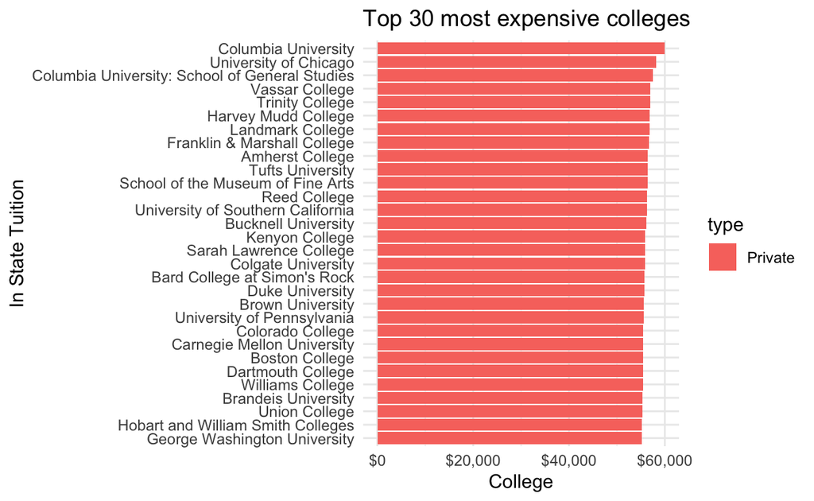

```r
tuition_cost <- tuesdata$tuition_cost

tuition_cost %>%
  top_n(30, wt = in_state_tuition) %>%
  mutate(name = forcats::fct_reorder(name, in_state_tuition)) %>%
  ggplot(aes(x = name, y = in_state_tuition, fill = type)) +
  geom_col() +
  coord_flip() +
  scale_y_continuous(labels = scales::dollar_format()) +
  labs(title = "Top 30 most expensive colleges") +
  ylab("College") +
  xlab("In State Tuition")
```

tidybayes can be used to plot the distribution of in state costs and out of state costs.

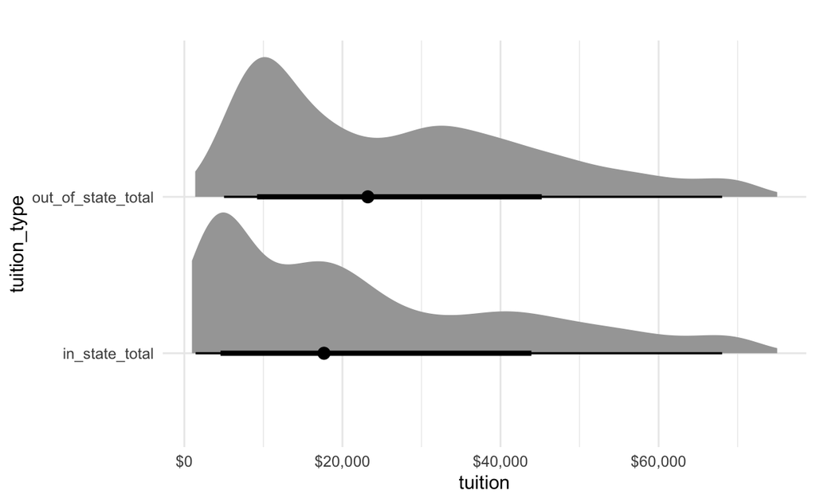

```r
tuition_cost %>%
  group_by(type) %>%
  pivot_longer(c("out_of_state_total", "in_state_total"), names_to = "tuition_type", values_to = "tuition") %>%
  ggplot(aes(x = tuition, y = tuition_type)) +
  stat_halfeyeh() +
  scale_x_continuous(labels = scales::dollar_format()) +
  labs(title = "")
```

## Historical Tuition Data

Another dataset contains the historical tuition values in adjusted US dollars. We can see that private and public tuitions have doubled for four year courses since 1985. It’s quite a lot more expensive to attend college in the US now than it was 35 years ago!

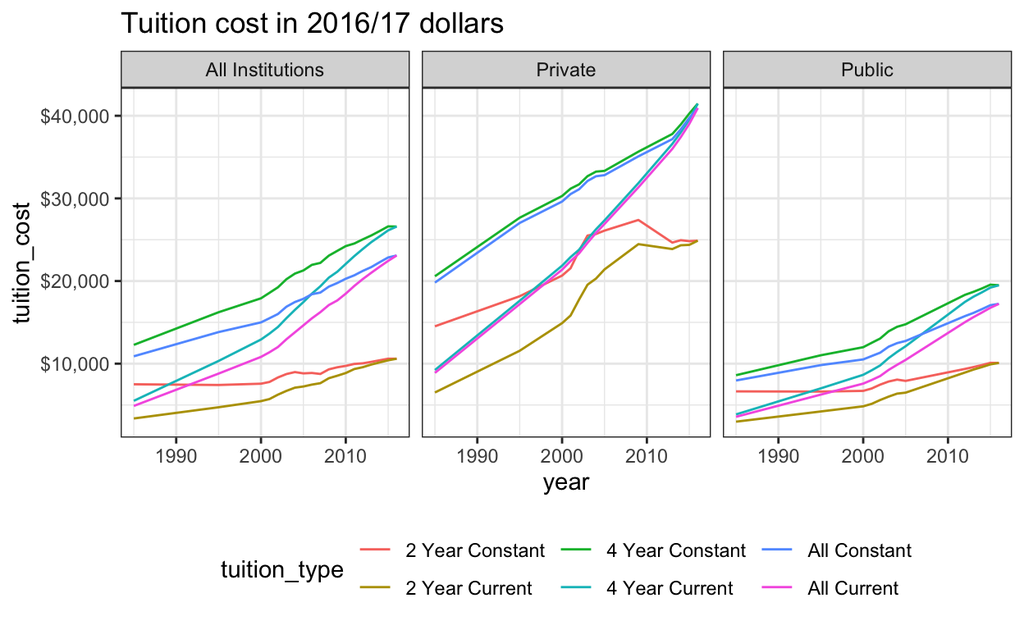

```r
tuesdata$historical_tuition %>%
  mutate(year = substr(year, 1, 4) %>% as.numeric()) %>%
  ggplot(aes(x = year, y = tuition_cost, colour = tuition_type)) +
  geom_line() +
  facet_wrap(~type, ncol = 3) +
  theme_bw() +
  theme(legend.position = "bottom") +
  scale_y_continuous(labels = scales::dollar_format()) +
  labs(title = "Tuition cost in 2016/17 dollars")
```

## State tuition map

The package urbnmapr allows us to plot US states and overlay information at a state level.

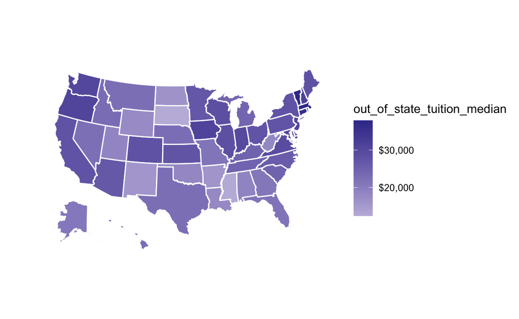

```r
tuition_cost <- tuesdata$tuition_cost

states_sf <- get_urbn_map("states", sf = TRUE)

tuition_by_state <- states_sf %>%
  rename(state_code = state_abbv) %>%
  inner_join(tuition_cost, by = "state_code") %>%
  filter(degree_length == "4 Year") %>%
  group_by(state_code) %>%
  summarise_if(is.numeric, list(~mean(.), ~median(.)))

tuition_by_state %>%
  ggplot() +
  geom_sf(color = "#ffffff", aes(fill = out_of_state_tuition_median)) +
  scale_fill_gradient2(labels = scales::dollar_format()) +
  coord_sf(datum = NA)
```

## Most cost effective Universities

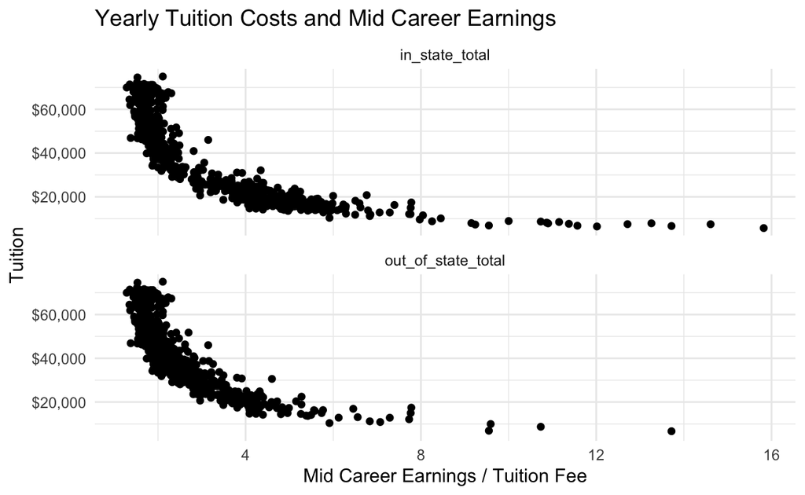

```r
salary <- tuesdata$salary_potential

salary %>%
  left_join(tuesdata$tuition_cost %>% filter(degree_length == "4 Year")) %>%
  pivot_longer(c("out_of_state_total", "in_state_total"), names_to = "tuition_type", values_to = "tuition") %>%
  mutate(ratio = mid_career_pay / tuition,
         name_cost = paste(name, scales::dollar(tuition))) %>%
  ggplot(aes(x = ratio, y = tuition)) +
  geom_point() +
  facet_wrap(~tuition_type, ncol = 1) +
  scale_y_continuous(labels = scales::dollar_format()) +
  xlab("Mid Career Earnings / Tuition Fee") +
  ylab("Tuition") +
  labs(title = "Yearly Tuition Costs and Mid Career Earnings")
```

# Net cost by income bracket

Using tidybayes again to view the distribution of the net-costs by income bracket. The data has a peak at zero for those receiveing full scholarships. Interesting they seem most prevelant for those with an income over £110,000!

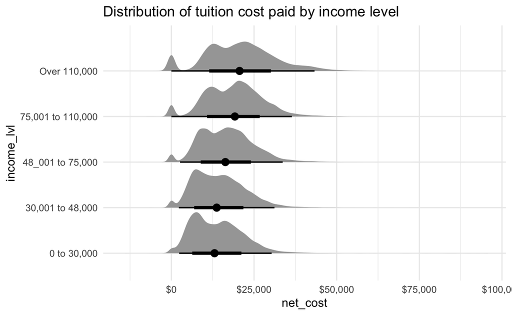

```r
tuesdata$tuition_income %>%
  ggplot(aes(y = income_lvl, x = net_cost)) +
  stat_halfeyeh() +
  scale_x_continuous(labels = scales::dollar_format()) +
  labs(title = "Distribution of tuition cost paid by income level")
```

# Diversity of top 20 Forbes Colleges

To create a chart of diversity such as that on the [priceonomics](https://priceonomics.com/ranking-the-most-and-least-diverse-colleges-in/) blog I took the top 20 colleges according to Forbes [from wikipedia](https://en.wikipedia.org/wiki/Rankings_of_universities_in_the_United_States#Forbes_college_rankings). I copied the table to an R tribble using [data pasta](https://cran.r-project.org/web/packages/datapasta/vignettes/how-to-datapasta.html).

```r
top_unis <- tibble::tribble(
                              ~name, ~ranking,
                     "Harvard University", 1,
                    "Stanford University", 2,
                        "Yale University", 3,
  "Massachusetts Institute of Technology", 4,
                   "Princeton University", 5,
             "University of Pennsylvania", 6,
                       "Brown University", 7,
     "California Institute of Technology", 8,
                        "Duke University", 9,
                      "Dartmouth College", 10,
                     "Cornell University", 11,
                         "Pomona College", 12,
     "University of California, Berkeley", 13,
                    "Columbia University", 14,
                  "Georgetown University", 15,
                  "University of Chicago", 16,
                "Northwestern University", 17,
               "University of Notre Dame", 18,
       "Rensselaer Polytechnic Institute", 19,
                 "University of Michigan", 20
  )
```

The [Herfindahl-Hirschman index](https://en.wikipedia.org/wiki/Herfindahl%E2%80%93Hirschman_Index) is used as a measure of diversity at each college. The general formula is:

$$HHI = \sum_{i=1}^Na^2_i$$

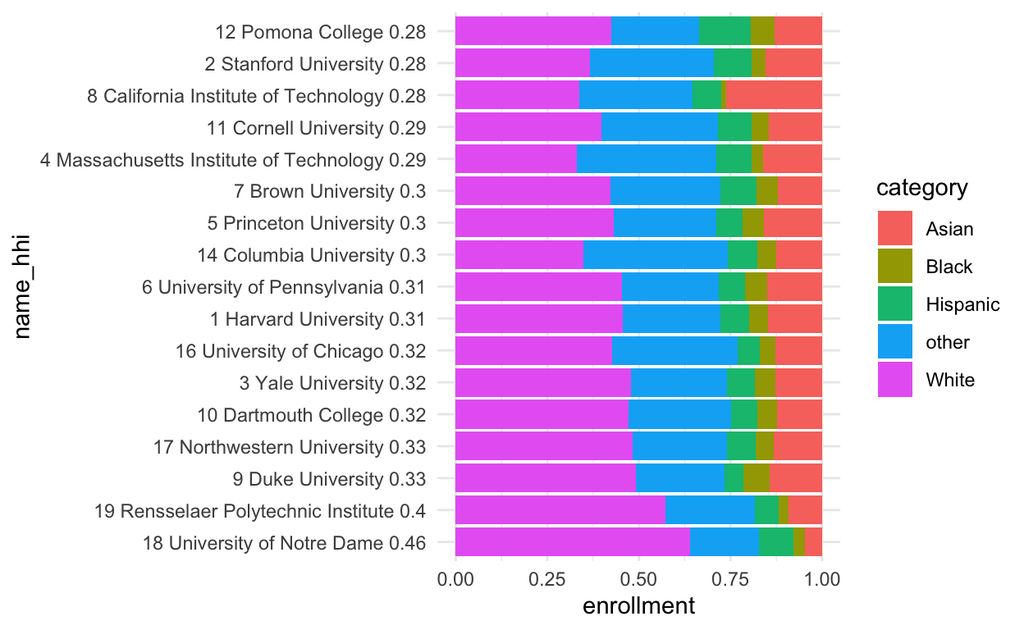

```r
diversity <- tuesdata$diversity_school

racial_diversity <- diversity %>%
  filter(!is.na(name)) %>%
  filter(category %in% c("White", "Black", "Hispanic", "Asian")) %>%
  pivot_wider(names_from = category, values_from = enrollment) %>%
  mutate(other = total_enrollment - White - Black - Hispanic - Asian) %>%
  pivot_longer(4:8, names_to = "category", values_to = "enrollment") %>%
  group_by(name) %>%
  mutate(hhi = sum((enrollment / total_enrollment) ** 2))

racial_diversity %>%
  inner_join(top_unis) %>%
  ungroup() %>%
  mutate(
    name_hhi = paste(ranking, name, round(hhi, 2)),
    name_hhi = forcats::fct_reorder(name_hhi, desc(hhi))) %>%
  filter(ranking <= 20) %>%
  ggplot() +
  geom_col(aes(y = name_hhi, x = enrollment, fill = category), position = "fill")
```

The next plot considers diversity as measured by HHI against potential earnings at mid career. This is the plot I chose to tweet for tidy tuesday.

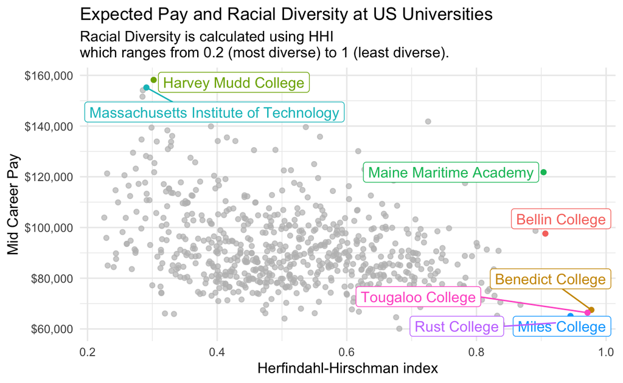

```r
racial_diversity %>%
  inner_join(salary, by = c("name")) %>%
  distinct(name, hhi, mid_career_pay) %>%
  ggplot(aes(x = hhi, y = mid_career_pay, colour = name)) +
  geom_point() +
  gghighlight(mid_career_pay > 1.55e5 |
                hhi > 0.9, use_direct_label = TRUE) +
  scale_y_continuous(labels = scales::dollar_format()) +
  labs(
    title = "Expected Pay and Racial Diversity at US Universities",
    subtitle = "Racial Diversity is calculated using HHI\nwhich ranges from 0.2 (most diverse) to 1 (least diverse).") +
    ylab("Mid Career Pay") +
    xlab("Herfindahl-Hirschman index")
```

```r
# ggsave("diversity.png")
```

# Tweet

Now use the [rtweet](https://rtweet.info/) library to post the plots directly to Twitter without leaving R. You must connect to the Twitter API using OAuth as described in [this vignette](https://rtweet.info/articles/auth.html), I set the Twitter application keys in my `.Renviron` file which is never committed to public version control (this can be easily edited using `usethis::edit_r_environ()`).

```r
library(rtweet)

token <- create_token(
  app = "rstats",
  consumer_key = Sys.getenv("TWITTER_API_KEY"),
  consumer_secret = Sys.getenv("TWITTER_API_SECRET_KEY"),
  access_token = Sys.getenv("TWITTER_ACCESS_TOKEN"),
  access_secret = Sys.getenv("TWITTER_ACCESS_TOKEN_SECRET"))
```

The function `post_tweet` can be used to post a new tweet.

```r
post_tweet(
  status = "This week's #TidyTuesday features diversity, tuition costs and expected salaries at US universities. It appears more diverse colleges tend to have higher earning graduates. #rstats",
  media = c("diversity.png", "carbon.png"),
  token = token
)
```